# DO3 - Formatage de tableaux de données

2025-01-15

## Approfondissement sur `ggplot`

## Un graphique sympa

Pendant le dernier TP, vous avez pu créer le graphique suivant :

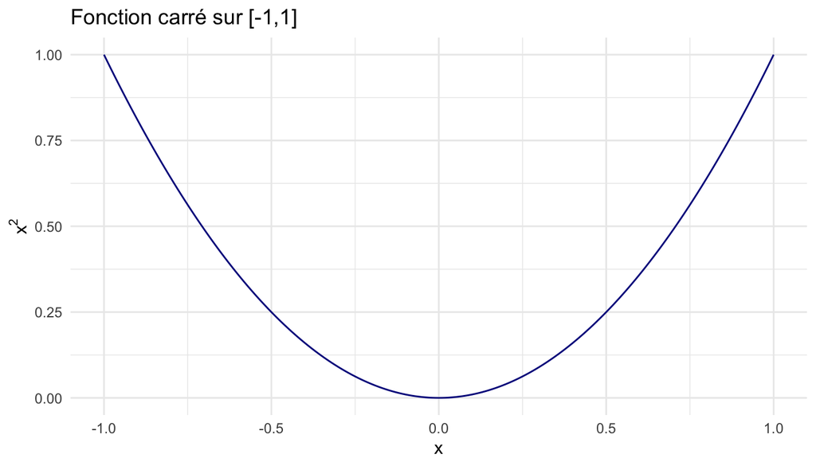

Votre premier graphique (normalement).

## Apprendre à enrichir le graphique

Mais si j’avais besoin de mettre plusieurs courbe dans le même graphique comment je peux faire ?

## Nouveau graphique

J’aimerais maintenant tracer tous les monômes de degré 2 à 5 sur le même graphique.

**Mais comment faire ??? :(**

Heureusement, `ggplot` est trop puissant et nous permet de faire ce que l’on souhaite à conditon d’avoir un jeu de données sous le bon format.

## Jeu de données

Voilà les valeurs sur \([-1,1]\) des monômes pour chaque degré.

```
##         x    valeur degré
## 1   -1.00  1.000000     2
## 2   -0.99  0.980100     2
## 202 -1.00 -1.000000     3
## 203 -0.99 -0.970299     3
## 403 -1.00  1.000000     4
## 404 -0.99  0.960596     4
## 604 -1.00 -1.000000     5
## 605 -0.99 -0.950990     5
```

Pour séparer en plusieurs courbe pour chaque monome, on utilise l’argument `color` de `aes()`.

## Graphique final

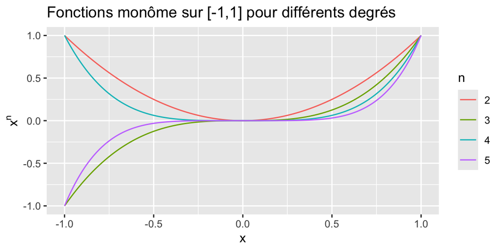

```r
ggplot(data) +
  aes(x = x, y = valeur, color = degré) +
  geom_line() +
  labs(title = "Fonctions monôme sur [-1,1] pour différents degrés",
       x = "x", y = expression(x^n), color = "n")
```

## Graphique alternatif

On peut aussi séparer chaque graphique (avec `facet_wrap()`) :

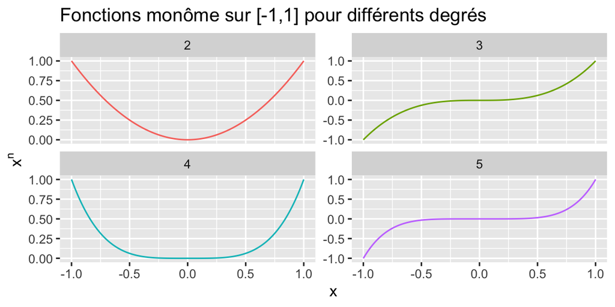

```r
ggplot(data) +
  aes(x = x, y = valeur, color = degré) +
  geom_line(show.legend = F) + facet_wrap(~degré, scales = "free_y") +
  labs(title = "Fonctions monôme sur [-1,1] pour différents degrés",
       x = "x", y = expression(x^n))
```

## Très bien mais…

Imaginons maintenant que le tableau de données soit comme ceci :

```
##       x    x_2       x_3       x_4        x_5
## 1 -1.00 1.0000 -1.000000 1.0000000 -1.0000000
## 2 -0.99 0.9801 -0.970299 0.9605960 -0.9509900
## 3 -0.98 0.9604 -0.941192 0.9223682 -0.9039208
## 4 -0.97 0.9409 -0.912673 0.8852928 -0.8587340
## 5 -0.96 0.9216 -0.884736 0.8493466 -0.8153727
## 6 -0.95 0.9025 -0.857375 0.8145062 -0.7737809
```

Le code de tout à l’heure ne marche plus…

## Formatage de jeux de données

## SQL

Un langage vachement pratique pour faire de la base de données et pour formater ces derniers est le `SQL`.

Il existe des packages utiles qui reproduisent les commandes `SQL`directement en temps réel.

## Le monde de `tidyverse`

\(\hookrightarrow\) regroupe plusieurs libraries utiles pour les sciences des données :

- `ggplot2` que vous connaissez déjà.
- `tibble` utilisation un type autre que `data.frame` qui nécessite avoir une bonne hygiène dans la manipulation des données.
- `dplyr` regroupe toute une grammaire pour manipuler des jeux de données.
- `tidyr` pour pouvoir bien structurer les jeux de données (compatible avec `tibble`)

## Quelques commandes `dplyr`

- `select()` : va sélectionner un sous-ensemble de variable (donc les colonnes) que vous avez choisi.
- `slice()` : sélectionne des lignes.
- `filter()` : va sélectionner les individus qui vérifie une condition.
- `mutate()` : crée une nouvelle colonne, calculable à partir des variables du jeu de données.

## Exemple

Prenons ce jeu de données simple :

```
## # A tibble: 10 × 2
##        x   x_2
##    <dbl> <dbl>
##  1 -1    1
##  2 -0.99 0.980
##  3 -0.98 0.960
##  4 -0.97 0.941
##  5 -0.96 0.922
##  6 -0.95 0.902
##  7 -0.94 0.884
##  8 -0.93 0.865
##  9 -0.92 0.846
## 10 -0.91 0.828
```

## Exemple 1

On aimerait prendre uniquement l’image de la fonction entre \([0,1]\) :

```r
head(filter(data, x>=0))
```

```
## # A tibble: 6 × 2
##        x      x_2
##    <dbl>    <dbl>
## 1 0      0
## 2 0.0100 0.000100
## 3 0.0200 0.000400
## 4 0.0300 0.000900
## 5 0.0400 0.00160
## 6 0.0500 0.00250
```

## Exemple 2

On aimerait ajouter une nouvelle colonne représentant la fonction \(x \mapsto x^2+x\) :

```r
head(mutate(data, new = x + x_2))
```

```
## # A tibble: 6 × 3
##       x   x_2      new
##   <dbl> <dbl>    <dbl>
## 1 -1    1      0
## 2 -0.99 0.980 -0.00990
## 3 -0.98 0.960 -0.0196
## 4 -0.97 0.941 -0.0291
## 5 -0.96 0.922 -0.0384
## 6 -0.95 0.902 -0.0475
```

## Exemple 3

On aimerait sélectionner juste la colonne `x_2` :

```r
head(select(data, x_2))
```

```
## # A tibble: 6 × 1
##     x_2
##   <dbl>
## 1 1
## 2 0.980
## 3 0.960
## 4 0.941
## 5 0.922
## 6 0.902
```

## Exemple plus compliqué

On aimerait sélectionner la nouvelle fonction définie uniquement sur \([0,1]\) avec la valeur de \(x\) correspondante :

```r
head(select(filter(mutate(data, new = x + x_2), x >= 0), x, new))
```

```
## # A tibble: 6 × 2
##        x    new
##    <dbl>  <dbl>
## 1 0      0
## 2 0.0100 0.0101
## 3 0.0200 0.0204
## 4 0.0300 0.0309
## 5 0.0400 0.0416
## 6 0.0500 0.0525
```

(là, ça commence à être dur de suivre le code…)

## Le pipe

Il existe un moyen de rendre plus lisible toute ces commandes : le **pipe**.

## Le pipe

Le pipe `|>` est une commande qui permet d’envoyer un élément dans le premier argument d’une fonction.

```r
var1 |> fonction(arg2 = var2, ...)
# est la même chose que
fonction(arg1 = var1, arg2 = var2, ...)
```

\(\hookrightarrow\) facilite la lisibilité, surtout quand on enchaîne des commandes `dplyr`

## Exemple précédent

La commande :

```r
select(filter(mutate(data, new = x + x_2), x >= 0), x, new)
```

équivaut à :

```r
data |>
  mutate(new = x + x_2) |>    # création nouvelle variable
  filter(x >= 0) |>           # filtrage sur les lignes où x >= 0
  select(x, new)              # sélection des variables intéressantes
```

Bien plus lisible je trouve.

## Code compact

Le pipe est utilisable partout, même sur `ggplot` :

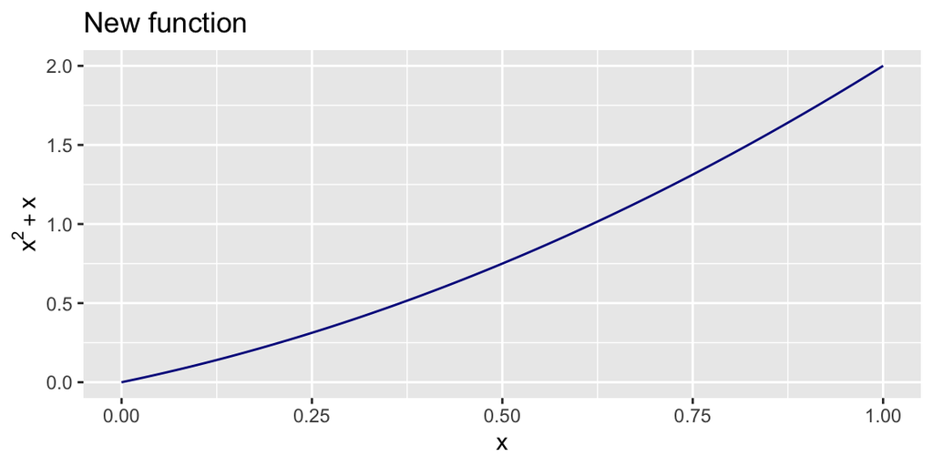

```r
data |> mutate(new = x + x_2) |>
  filter(x >= 0) |> select(x, new) |>
  ggplot() + aes(x = x, y = new) + geom_line(col = "darkblue") +
    labs(x = "x", y = expression(x^2 + x), title = "New function")
```

## Retour sur le jeu de données

Comment régler ce problème de `ggplot` ?

```r
data2 <- data.frame(x = x, x_2 = x**2, x_3 = x**3, x_4 = x**4, x_5 = x**5)
head(data2)
```

```
##       x    x_2       x_3       x_4        x_5
## 1 -1.00 1.0000 -1.000000 1.0000000 -1.0000000
## 2 -0.99 0.9801 -0.970299 0.9605960 -0.9509900
## 3 -0.98 0.9604 -0.941192 0.9223682 -0.9039208
## 4 -0.97 0.9409 -0.912673 0.8852928 -0.8587340
## 5 -0.96 0.9216 -0.884736 0.8493466 -0.8153727
## 6 -0.95 0.9025 -0.857375 0.8145062 -0.7737809
```

## Une commande `tidyr` pratique

Dans la librairie `tidyr`, il y a une fonction pratique nommé `pivot_longer()`.

\(\hookrightarrow\) permet de fusionner des colonnes en unique variable.

\(\hookrightarrow\) crée une nouvelle variable indiquant de quelle variable la valeur provient.

## Utilisation sur notre exemple

```r
data2 |>
  pivot_longer(cols = c(x_2, x_3, x_4, x_5)) |> head()
```

```
## # A tibble: 6 × 3
##       x name   value
##   <dbl> <chr>  <dbl>
## 1 -1    x_2    1
## 2 -1    x_3   -1
## 3 -1    x_4    1
## 4 -1    x_5   -1
## 5 -0.99 x_2    0.980
## 6 -0.99 x_3   -0.970
```

On a donc les 4 variable qui ont fusionné en une variable `value` et on a crée une autre variable `name`, dite “informative”, qui nous indique d’où provient la valeur de la ligne.

## Quelques arguments utiles

Il y a des arguments supplémentaires facilitant ensuite la construction du `ggplot` :

- `values_to=` : pour indiquer le nom de la variable fusionnée.
- `names_to=` : pour indiquer le nom de la variable informative.
- `names_prefix=` : utile pour supprimer le début des variables initiales lors de leur transcription en modalités de la variable informative.

## Version finale

```r
data2 |>
  pivot_longer(cols = starts_with("x_"),
               values_to = "Valeurs",
               names_to = "Degré",
               names_prefix = "x_") |>
  filter(x == -1)
```

```
## # A tibble: 4 × 3
##       x Degré Valeurs
##   <dbl> <chr>   <dbl>
## 1    -1 2           1
## 2    -1 3          -1
## 3    -1 4           1
## 4    -1 5          -1
```

et on retombe sur le même tableau que tout à l’heure qui est compatible avec une utilisation de `ggplot`.